# MATH5741M: Statistical Theory and Methods

Benjamin Thorpe

2022-01-17

Benjamin Thorpe (b.thorpe@leeds.ac.uk)  
Monday January 17, 2022

This is the collection of exercises that you are encouraged to complete to reinforce what you will learn in lectures and practicals. I will suggest one or two exercises to complete each week. You should submit them by **2pm each Monday** via [Gradescope](https://www.youtube.com/watch?v=KMPoby5g_nE), which can be found in Minerva. You **do not** need to sign up to the Gradescope website, you should instead access it only through Minerva.

All exercises will be marked out of $4$, as shown below. The goal of this marking scheme is to clearly indicate what actions you should take in response to your mark. I hope that this will be more helpful for your learning than just being given a grade.

- $4/4$ = “Perfect or almost perfect.”
- $3/4$ = “A few minor errors that require attention, but nothing serious.”
- $2/4$ = “Either many minor errors or a few serious errors. You should at least check the solutions provided.”
- $1/4$ = “Many serious errors or clear misunderstandings. You should check the solutions provided and review the theory and examples in the notes.”

These are not the only exercises that you should attempt during this module. It is important that you develop the ability to find further exercises to complete through textbooks and websites. You should look for exercises similar in style and difficulty to the exercises on this sheet.

# Exercises

The first two exercises will help me to judge your grasp of calculus, and to help you to identify any gaps in your knowledge. These questions represent roughly the level of calculus that is expected for this module. If you struggle, **please let me know** as soon as possible.

**Exercise 1 (integration)** Evaluate the integral
$$\int_{10}^{\infty}0.2\, e^{-0.2 u}du.$$

**Exercise 2 (differentiation)** Consider a function $L: (0, \infty) \rightarrow \mathbb{R}$ defined by
$$L(\lambda) = \lambda^{10}e^{-\lambda} \lambda^{50}e^{-\lambda} \lambda^{90}e^{-\lambda}.$$

1. Simplify the function $L(\lambda)$ as far as possible.
2. Find the first derivative $dL/d\lambda$ and show that the second derivative is
   $$\frac{d^{2}L}{d\lambda^{2}} = -3\lambda^{149}e^{-3\lambda} + (150 - 3\lambda)\left(149 - 3\lambda \right)\lambda^{148}e^{-3\lambda}.$$
3. Find a stationary point of $L(\lambda)$. Is this point a maximum or a minimum?
4. Define a new function $\ell(\lambda) = \log L(\lambda)$ and simplify.
5. By differentiating, find a stationary point of $\ell(\lambda)$.
6. By finding the second derivative, show that this stationary point gives a local maximum for $\ell(\lambda)$.

If necessary, please look up the definitions of “stationary point” and “local maximum”. These were not defined in the lectures.

**Exercise 3 (probability)** A laboratory blood test is $90\%$ effective in detecting a certain disease when it is in fact present. However, the test also yields a “false positive” result for $1\%$ of healthy people tested. Suppose that $0.2\%$ of the population actually have the disease. What is the probability (to $2$ decimal places) that a person with a positive test result actually has the disease? Hint: start by trying to write down all of the relevant events and probabilities, and decide whether each of these is a conditional probability or not.

**Exercise 4 (numerical summaries)** Consider the data
$$18, \;\;18, \;\;19, \;\;22, \;\;22, \;\;23, \;\;25, \;\;25, \;\;25, \;\;28, \;\;30, \;\;31, \;\;33, \;\;37, \;\;41.$$
Using the formulae from lectures, calculate the mean, variance, standard deviation, median and quartiles. Check your answers using R.

**Exercise 5 (graphical summaries)** Consider again the data
$$18, \;\;18, \;\;19, \;\;22, \;\;22, \;\;23, \;\;25, \;\;25, \;\;25, \;\;28, \;\;30, \;\;31, \;\;33, \;\;37, \;\;41.$$
Using the intervals
$$I_{1} = [0, 20),\;\; I_{2} = [20, 40), \;\; I_{3} = [40,50),$$

1. Write down the frequency distribution of the data and draw a histogram by hand.
2. Should the vertical axis in your histogram be frequency or density? Explain your answer.

Check your histogram using the `hist()` function in R.

**Exercise 6 (correlation)** Consider the data set in the following table:

| $x_i$ : | 3 | 3.5 | 4 | 5 | 6 | 7 | 10 | 12 | 19.5 | 30 |
| --- | --- | --- | --- | --- | --- | --- | --- | --- | --- | --- |
| $y_i$ : | 11 | 11.0 | 17 | 13 | 14 | 24 | 16 | 3 | 3.0 | 0 |

Given that $\overline{x} = 10$, $\overline{y} = 11.2$, $s_x = 8.6$ and $s_y = 7.4$, calculate the sample correlation for this data set (without using the `cor()` function in R).

**Exercise 7 (heart surgery)** Open heart surgery can be performed via either the standard method (splitting the breastbone via a full ten-inch incision) or via minimally invasive techniques requiring a much smaller incision. Suppose that $20\%$ of surgeries performed via minimally invasive techniques require conversion to a full incision due to complications. If $100$ patients undergo minimally invasive surgery, what is the probability of the following events?

1. Exactly $20$ will require conversion. Hint: even though conversion is undesirable, think of a surgery requiring conversion as a “successful trial”.
2. Either $15$ or $16$ will require conversion.
3. The first patient who requires conversion will be the third operated on.
4. At least ten ($\geq 10$) patients not requiring a conversion will be operated on before the first patient requiring a conversion (i.e. strictly more than ten patients will be operated on before the first conversion is performed). Hint: what is the probability of no conversions in the first $10$ operations?

You can use R as a calculator for this exercise (e.g. to evaluate factorials and powers), but you should carefully write out each mathematical step of your calculations. You can then use the built-in R functions to check your probabilities at the end it you want to.

**Exercise 8 (normal distribution)** Given $X\sim N(1, 2^2)$, find ${\mathsf P}(X<3)$ and ${\mathsf P}(X<-3)$ **using the tables**. **Do not** just write down the probabilities with no explanation of how they were obtained.

**Exercise 9 (expectation and variance)** Let $X \sim U[0, \theta]$ for an unknown parameter $\theta >0$.

1. By integration, find the expectation of $X$ in terms of $\theta$.
2. By integration, find the variance of $X$ in terms of $\theta$.
3. Suppose that we observe a sample $\{x_{1},\ldots, x_{n}\}$ from this distribution. Find the method of moments estimate of $\theta$.

Show your steps clearly.

**Exercise 10 (estimation)** Let $X \sim Bin(1, p)$ for an unknown parameter $p \in (0, 1)$. Find the log-likelihood for a realisation $\{x_{1},\ldots, x_{4}\}= \{0,1,1,0\}$ of a random sample from this distribution. Show that its first derivative is
$$\frac{d\ell}{d p} = \frac{4\overline{x}}{p} - \frac{4 - 4\overline{x}}{1-p}$$
and thus find the maximum likelihood estimate of $p$. What would the method of moments estimate be for the same sample?

**Exercise 11 (estimation of two parameters)** Recall that a normal distribution has a density function of the form:
$$f(x) =\dfrac{\exp\left[-{\left( x-\mu \right)^{2}/2\sigma^{2}} \right]}{\sqrt{2\pi\sigma^2}} \;.$$

1. For realisations of an IID sample $x_1,\ldots,x_n \sim N(\mu, \sigma^2)$, write down the likelihood function and the log likelihood function
2. By differentiating the log likelihood with respect to $\mu$, find a possible MLE of $\mu$.
3. By differentiating the log likelihood with respect to $\sigma$, find a possible MLE of $\sigma^2$. Hint: finding a value of $\sigma > 0$ that maximises the log likelihood will also give us the value of $\sigma^2$ that maximises the log likelihood.

Note: This might be a difficult exercise if you do not have a maths background (but please don’t worry that all exercises will be so difficult). The tricky part is that when we differentiate with respect to each parameter, we need to take **partial derivatives**. In other words, we differentiate with respect to $\mu$ while treating $\sigma$ like a constant, then we differentiate with respect to $\sigma$ while treating $\mu$ like a constant.

**Exercise 12 (bias and MSE)** Consider a continuous random variable $X$ whose probability density function is
$$f(x) = \begin{cases} 2x / \theta^2 & x \in (0, \theta] \\ 0 & \text{otherwise}\end{cases}$$
with unknown parameter $\theta > 0$. Suppose that we will take a random sample of size $n$ from this distribution, $\{X_{1},\ldots, X_{n}\}$, which we assume to be independent and identically distributed.

1. Show that ${\mathsf E}(X) = 2\theta/3$ and $\text{var}(X) = \theta^2/18$.
2. Find the method of moments estimator, $\widehat{\theta}_{mom}$, for $\theta$.
3. Find the bias and mean squared error of $\widehat{\theta}_{mom}$. Comment on what happens if we increase the sample size.
4. Show that the maximum likelihood estimator for $\theta$ is
   $$\widehat{\theta}_{mle} = max \{X_{1}, \ldots, X_{n}\}.$$
   Hint: Look up the maximum likelihood estimator for a uniform distribution and how it is found. You can assume here, without differentiating, that $-\log\theta$ is a decreasing function of $\theta$.
5. For a random sample $\{X_{1}\}$ of size $n = 1$, what are the bias and mean squared error of $\widehat{\theta}_{mle}$? Which estimator, $\widehat{\theta}_{mle}$ or $\widehat{\theta}_{mom}$, would you prefer in this situation?

**Exercise 13 (estimation, bias and MSE, again)** Consider a random variable $X$ that takes values in the set $\{-1, 0, 1\}$. The distribution of $X$ has a probability mass function
$$f(x) = \left\{\begin{array}{ll}
-\alpha + 0.1 & \;\;\textrm{if } x = -1\\
-\alpha + 0.8 & \;\;\textrm{if } x = 0\\
2\alpha + 0.1 & \;\;\textrm{if } x = 1\\
\end{array}\right.$$
that depends on a parameter $\alpha \in [0,0.1]$. Suppose that we observe an independent and identically distributed random sample of size $n$ from this distribution, $\{x_1, \ldots, x_n\}$.

1. Show that the method of moments estimator of $\alpha$ is
   $$\widehat\alpha = \overline{X}/3$$
   and find its bias and mean squared error.
2. If $n$ is large, what is the approximate sampling distribution of this estimator? What are its parameters? Comment on what happens as $n$ is increased.
3. If we take a sample of size $n=1$, what is the maximum likelihood estimate of $\alpha$?
4. If we take a sample of size $n = 2$ and observe $\{-1, -1\}$, show that the first derivative of the log likelihood is
   $$\frac{-2}{-\alpha + 0.1}$$
   What is the maximum likelihood estimate of $\alpha$?

Note: problems like this (based on finding and assessing estimators) are an important part of the module and are likely to appear on the exam. Please don’t assume that they can simply be avoided.

**Exercise 14 (CLT)** Suppose a population has mean $50$, and standard deviation $15$, but that we do not know the distribution beyond this information. If we take a random sample of size $90$ from this population, what is the (approximate) probability that the sample mean will be:

1. more than $52$,
2. less than $45$,
3. between $45$ and $55$?

For what value of $c$ would we achieve

$${\mathsf P}\left({50-\frac{15c}{\sqrt{90}}< \overline{X} < 50+\frac{15c}{\sqrt{90}}}\right) \approx 0.9?$$

**Exercise 15 (t test)** The table below shows labour force participation rate of women in $1968$ and $1972$. We want to test, at the $5\%$ level, the hypothesis that the percentage of women in work has not changed in this period.

| City | 1972 | 1968 |
| --- | --- | --- |
| New York | 0.45 | 0.42 |
| Los Angeles | 0.50 | 0.50 |
| Chicago | 0.52 | 0.52 |
| Philadelphia | 0.45 | 0.45 |
| Detroit | 0.46 | 0.43 |
| San Francisco | 0.55 | 0.55 |
| Boston | 0.60 | 0.45 |
| Pitt. | 0.49 | 0.34 |
| St. Louis | 0.35 | 0.45 |
| Connecticut | 0.55 | 0.54 |
| Wash., D.C. | 0.52 | 0.42 |
| Cinn. | 0.53 | 0.51 |
| Baltimore | 0.57 | 0.49 |
| Newark | 0.53 | 0.54 |
| Minn/St. Paul | 0.59 | 0.50 |
| Buffalo | 0.64 | 0.58 |
| Houston | 0.50 | 0.49 |
| Patterson | 0.57 | 0.56 |
| Dallas | 0.64 | 0.63 |

1. State and test your hypotheses.
2. What are your assumptions?
3. What are your conclusions?
4. Calculate the p-value for your test.

What would a type 1 or type 2 error mean in this example? Perform your hypothesis test by hand, using the tables given to you in lectures. You can use R to find the probabilities needed to calculate the p-value, but do not use the `t.test()` function. Show the steps in your calculation clearly.

**Exercise 16 (revision)** It is suggested that exam revision has an effect on student quality of life. In a random sample of $n = 5$ MSc students, quality of life was assessed on a scale of $0$ (death) to $100$ (perfect) both before and during revision for a statistics exam.

| Student: | 1 | 2 | 3 | 4 | 5 |
| --- | --- | --- | --- | --- | --- |
| Before: | 90 | 80 | 60 | 80 | 50 |
| During: | 50 | 60 | 20 | 20 | 10 |

1. Explain briefly why these should not be treated as $10$ independent observations. The sample correlation between $x$ and $y$ here is $0.76$. Why does this support your answer?
2. Using the t distribution, calculate a $99\%$-confidence interval for the population average of difference between quality of life before revision and quality of life during revision. Clearly state any assumptions that you make.
3. Interpret your confidence interval and use it to test the hypothesis that exam revision does not affect average quality of life.
4. State what a type 1 error and a type 2 error would be in the context of this example.
5. Suppose that we repeat this experiment with a sample of $n = 1000$ students. By plotting a histogram, we discover that the differences, $y_i - x_i$, are highly skewed. How should we change the calculation of our confidence interval?

**Exercise 17 (CLT)** Suppose that we take an independent and identically distributed sample $X_{1}, X_{2}, \ldots, X_{n}$ from the distribution of some random variable $X$.

1. Assuming that the sample size $n$ is large, which of the following can we assume by the central limit theorem?
   1. The sample mean is approximately normally distributed.
   2. $\sum_{i = 1}^{n}X_{i}$ is approximately normally distributed.
   3. Each of $X_{1}, X_{2}, \ldots, X_{n}$ is approximately normally distributed.
   4. $X$ is approximately normally distributed.
2. Suppose that our sample is taken from one of the following distributions. In which of these cases would the central limit theorem not apply?
   1. Normal.
   2. Binomial.
   3. Exponential.
   4. Uniform.
3. Which of the following expressions are true?
   1. ${\mathsf E}(X_{1} + X_{2} + \ldots + X_{n}) = {\mathsf E}(X_{1}) + {\mathsf E}(X_{2}) + \ldots + {\mathsf E}(X_{n})$.
   2. ${\mathsf E}(\sum_{i=1}^{n} X_{i}) = \sum_{i=1}^{n}{\mathsf E}(X_{i})$.
   3. ${\mathsf E}(\sum_{i=1}^{n} X_{i}) = \sum_{i=1}^{n}{\mathsf E}(X_{1})$.
   4. ${\mathsf E}(\sum_{i=1}^{n} X_{i}) = n{\mathsf E}(X_{1})$.
   5. $\sum_{i=1}^{n} X_{i} = n X_{1}$.

Note: in each of these scenarios, more than one statement can be true.

**Exercise 18 (hypothesis testing)** Suppose that a coin is tossed repeatedly to check if it is fair. In other words, we will test
$$H_{0}: \theta = 0.5 {\text{ (fair)}} \;\;\; vs. \;\;\; H_{1}: \theta \neq 0.5 {\text{ (not fair)}},$$
where $\theta$ is the probability of observing heads on a single toss. We take our test statistic to be $X$, the number of heads observed in $10$ independent tosses. We will reject the null if this statistic is observed to be improbably far from $5$.

1. What is the distribution of $X$?
2. If $H_{0}$ is true then ${\mathsf P}(X \leq 8) = 0.99$. What is the p-value for our hypothesis test if we observe a realisation $X = 9$ for our statistic?
3. If the coin is fair but we conclude it to be unfair, what kind of error is this?

**Exercise 19 (2021 exam)** Take a random sample of size $n = 4$ from a normal distribution $N(\mu, \sigma^2)$ by running the code `rnorm(4, 5, 3)`. Write down these four observations to one decimal place.

1. Assume that $\mu$ and $\sigma^2$ are not known. Which test would we apply to test the hypotheses $H_0: \mu = 5$ and $H_1: \mu \neq 5$? Explain your choice.
2. Without using R, perform this test by writing down an $80\%$ confidence interval for $\mu$. Write down clearly the quantile that you used in this calculation.
3. Given that $\mu = 5$, was your conclusion in part (b) a type 1 error, a type 2 error or neither?

**Exercise 20 (2021 exam)** Consider a normally distributed random variable $X \sim N(\mu, 1)$ with unknown mean $\mu$ but with variance known to be $1$. Consider an independent and identically distributed random sample of size $n = 2$ from this distribution, $\{X_{1}, X_{2}\}$. Consider two estimators of the parameter $\mu$ based on this sample:
$$\widehat{\mu}_1 = \frac{X_1 + X_2}{2} \;\;\; \text{and} \;\;\; \widehat{\mu}_2 = \frac{X_1 + 2X_2}{3}\;,$$
where the first estimator is the usual sample mean and the second is a weighted average of the two observations.

1. Calculate the bias of each estimator.
2. Calculate the variance of each estimator.
3. Which estimator do you prefer and why?

**Exercise 21 (2021 exam)** Write down the research area that interests you most (for example, medicine, biology, computer science or physics). Give an example of a question in this research area that could be answered by hypothesis testing. State your null and alternative hypotheses clearly. In the context of this example, describe the possible consequences of making a type 1 error and the possible consequences of making a type 2 error.

**Exercise 22 (2021 exam)** Consider a continuous random variable $X$ with density function
$$f(x) = 2\gamma x \exp\left(-\gamma x^2\right)$$
for $x > 0$ and $f(x) = 0$ for $x <0$, where $\gamma$ is an unknown parameter. Suppose that we take an independent and identically distributed random sample of size $n = 3$ from this distribution and observe realisations $\{x_1 = 2, x_2 = 1, x_3 = 1\}$.

1. Why can we immediately say that $\gamma >0$?
2. Find a maximum likelihood estimate for $\gamma$.
3. Write a function `f(x, gamma)` in R that evaluates the density $f(x)$ at any values of $x > 0$ and $\gamma > 0$. Use this function and your estimate of $\gamma$ to plot the density curve for $X$ in the interval $x \in (0, 10)$. (If you are unable to complete part (c) then just use $\gamma = 1$ here.)

**Exercise 23 (2021 exam)** Computer simulation programs are often used to assess cost effectiveness of medical treatments. Consider two different simulation programs: Program A and Program B. To determine which of these runs faster, an MSc student was given the task of randomly selecting $100$ university computers and running **both programs on each computer**, to allow direct speed comparisons. This produced $2$ samples of size $n = 100$: the running times (in seconds) for Program A and the running times (in seconds) for Program B. The student wrote the following short report on her findings:

**Report**

Running times for Program A were weakly correlated with those of Program B (sample correlation $r \approx 0.8$). The samples of running times ($x$) are summarised separately by program ($A$ and $B$) in the box plots and sample cumulative distribution functions (CDFs) below.

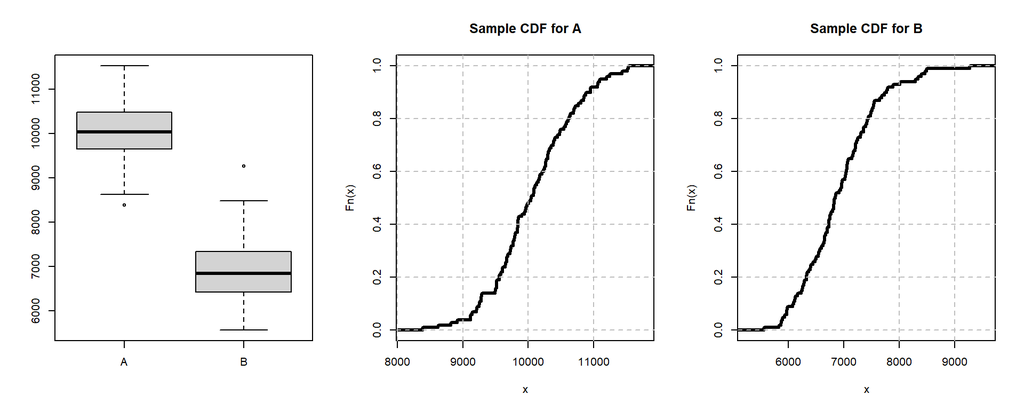

Figure 1: Boxplots and CDFs.

The sample CDFs have the same shape (both steadily increasing) and therefore do not suggest any differences between the two programs. The box plots noticeably differ, suggesting that the observations in each sample might be skewed and therefore might not come from normal distributions. However, by the central limit theorem and large sample sizes, we can assume that both samples come from normal distributions when we analyse the data.

The spread appears to be similar in the two box plots, suggesting equal variances, which is supported by sample standard deviations of $639$ and $677$ seconds for Programs A and B, respectively. This allows us to apply a two-sided, two-sample t-test using the R code

```r
t.test(timesA, timesB, var.equal = F, conf.level = 0.95)
```

where `times` and `timesB` are vectors containing the observed running times of Programs A and B, respectively. This gave sample means of $10063$ seconds for A and $6924$ seconds for B. The $95\%$-confidence interval for the mean difference was $(2955, 3322)$. This interval does not contain $0$, suggesting that the difference is nonzero, statistically significant at the $2.5\%$ level. The lower limit of the confidence interval tells us that Program A always took at least $2955$ seconds longer than B.

Read this report carefully and pay attention to the graphs.

1. Find and write down any problems with the student’s report.
2. Briefly outline how you would have analysed the data.
3. Based on the sample CDF for Program B, approximately what is the $80\%$ sample quantile? Approximately what is the probability that Program B will take between $8000$ and $18000$ seconds to run on a random computer?
4. Assume that running times are normally distributed for Program B and that the student’s estimates for the parameters of this normal distribution are accurate. Suppose that we will run Program B on $200$ independent computers. Denote the time taken for each run by $X_i$ for $i=1, \ldots, 200$. What is the probability that the **total** running time, $\sum_{i=1}^{n}X_i$, will be longer than $16$ days?

# More exercises

If you would like more practice, it is also possible to randomly generate your own problems and solutions via R. For example,

```r
x <- round(rnorm(n = 10, mean = 10, sd = 2))
x
```

will give a random sample from a normal distribution. You can summarise this sample numerically and graphically by hand, and then you can easily check your answers in R:

```r
par(mfrow = c(2,2))
mean(x); sd(x); var(x); quantile(x, type = 1)
plot(ecdf(x), verticals = T); hist(x); boxplot(x)
```

You can use R functions (`pnorm()`, `ppois()`, etc.) to produce your own probability exercises and solutions. For example, what is ${\mathsf P}(3\leq X \leq 7)$ for $X\sim N(10, 2^2)$? What if the distribution was $Geom(0.1)$ instead? You can work this out on paper using tables and then check your answer in R using

```r
pnorm(q = 7, mean = 10, sd = 2) - pnorm(q = 3, mean = 10, sd = 2)
pgeom(q = 7, prob = 0.1) - pgeom(q = 2, prob = 0.1)
```

Similarly, you can use R to generate your own examples to practice hypothesis testing and confidence intervals. You can generate a random sample via

```r
x <- round(rnorm(n = 10, mean = 10, sd = 2), 1)
x
```

work out the confidence interval using only pen, paper and statistical tables, then check your answer in R: `t.test(x, mu = 8, conf.level = 0.9)` tests $H_0: \mu = 8$. To get some practice using the tables, try doing this with confidence levels other than 95%.

# Solutions

## Solution to Exercise 1

$$\int_{10}^{\infty}\lambda e^{-0.2 u}du = \left[\frac{1}{-0.2}0.2 e^{-0.2u}\right]_{10}^{\infty} = \left[- e^{-0.2u}\right]_{10}^{\infty}$$
where we know that $- e^{-0.2u} \rightarrow 0$ as $u \rightarrow \infty$. Therefore
$$\int_{10}^{\infty}\lambda e^{-0.2 u}du = 0 - \left(-e^{-0.2 \times 10}\right)\approx 0.14.$$

## Solution to Exercise 2

1. $L(\lambda) = \lambda^{10+50+90}e^{-\lambda-\lambda-\lambda} = \lambda^{150}e^{-3\lambda}$.
2. By the product rule,
   $$\begin{eqnarray*}
   \frac{dL}{d\lambda} & = & \frac{d}{d\lambda}\left(\lambda^{150}\right)e^{-3\lambda} + \lambda^{150}\frac{d}{d\lambda}\left(e^{-3\lambda}\right)\\
   & = & 150\lambda^{150-1}e^{-3\lambda} + \lambda^{150}(-3)e^{-\lambda} = \left(150 -3 \lambda\right)\lambda^{149}e^{-3\lambda}.
   \end{eqnarray*}$$
   Applying the product rule again,
   $$\begin{eqnarray*}\frac{d^{2}L}{d\lambda^{2}} & =& \underbrace{\frac{d}{d\lambda}\left(150 -3 \lambda\right)}_{=-3}\lambda^{149}e^{-3\lambda} \\
   && + \left(150 -3 \lambda\right)\underbrace{\frac{d}{d\lambda}\left(\lambda^{149}e^{-3\lambda}\right)}_{=149\lambda^{148}e^{-3\lambda} - 3\lambda^{149}e^{-3\lambda}}
   \end{eqnarray*}$$
   and this simplifies to
   $$\frac{d^{2}L}{d\lambda^{2}} = -3\lambda^{149}e^{-3\lambda} + (150 - 3\lambda)\left(149 - 3\lambda \right)\lambda^{148}e^{-3\lambda}.$$
3. A stationary point occurs when $d L / d\lambda = 0$, which is equivalent to
   $$0 = \left(150 -3 \lambda\right)\lambda^{149}e^{-3\lambda}.$$
   We know that $e^{-3\lambda} > 0$ and that $\lambda^{149} > 0$ because $\lambda \in (0, \infty)$. Therefore the only possibility is $150 -3 \lambda = 0$, which gives
   $$\lambda = 150/3 = 50$$
   as our stationary point. To check if this is a maximum or minimum, we evaluate the second derivative at $\lambda = 50$,
   $$\begin{eqnarray*}
   \frac{d^{2}L}{d\lambda^{2}}(50) & = & -3\times 50^{149}e^{-3\times 50} + \underbrace{(150 - 3\times 50)}_{=0}\left(149 - 3\times 50 \right)50^{148}e^{-3\times 50}\\
   & = & -3\times 50^{149}e^{-150} < 0.
   \end{eqnarray*}$$
   Since the second derivative is negative, $\lambda = 50$ gives a local maximum for $L(\lambda)$.
4. By the usual rules for logs,
   $$\log L(\lambda) = \log\left(\lambda^{150}e^{-3\lambda}\right) = \log\lambda^{150} + \log e^{-3\lambda} = 150\log\lambda + (-3)\lambda\log e$$
   and we know that $\log e = 1$, since we always assume $\log$ denotes the natural logarithm unless stated otherwise. Therefore
   $$\ell(\lambda) = 150\log\lambda -3\lambda.$$
5. Differentiating,
   $$\frac{d\ell}{d\lambda} = 150\frac{1}{\lambda} - 3.$$
   Solving ${d\ell}/{d\lambda} = 0$ gives $\lambda = 50$ as our stationary point.
6. Differentiating again,
   $$\frac{d^{2}\ell}{d\lambda^{2}} = -150\frac{1}{\lambda^2}.$$
   Clearly ${d^{2}\ell}/{d\lambda^{2}} < 0$ at $\lambda = 50$, therefore $\lambda = 50$ gives a local maximum for $\ell(\lambda)$.

## Solution to Exercise 3

First we need some notation. Let $D$ denote the event that a person has the disease, and let $T$ denote the event that a test result is positive. We want to compute
$${\mathsf P}({D\mid T}).$$

We are told (in the question): ${\mathsf P}({T\mid D})=0.9, {\mathsf P}({T\mid D^c})=0.01, {\mathsf P}({D})=0.002$.

So we can quickly note: ${\mathsf P}({T^c\mid D})=0.1, {\mathsf P}({T^c\mid D^c})=0.99, {\mathsf P}({D^c})=0.998$.

Now, using the definition of conditional probability, we have:
$${\mathsf P}({T \cap D})={\mathsf P}({T\mid D})\times {\mathsf P}({D})=0.9\times 0.002 = 0.0018$$
$${\mathsf P}({T \cap D^c})={\mathsf P}({T\mid D^c})\times {\mathsf P}({D^c})=0.01\times 0.998 = 0.00998$$
We can partition the sample space into $D$ and $D^c$, so the law of total probability gives us
$${\mathsf P}({T})={\mathsf P}({T \cap D})+{\mathsf P}({T \cap D^c})=0.0018+0.00998=0.01178$$

Finally, again using the definition of conditional probability,
$${\mathsf P}({D\mid T})={\mathsf P}({D\cap T})/{\mathsf P}({T})=0.0018/0.01178=0.1528014\approx 0.15$$

Note that this is quite a low probability even though the test appeared to be effective. This is because the prevalence of the disease is very small.

## Solution to Exercise 4

The mean (and first moment about zero) is
$$\overline{x} =m_1(0)=\frac{1}{15}(18+18+\cdots+41) %= \frac{397}{15}
\approx 26.5$$
The sample variance is
$$\begin{eqnarray*}
s^2 & = & \frac{1}{n-1}\sum_{i=1}^n (x_i - \overline{x})^2\\
& \approx & \frac{1}{14}\left[(18 - 26.5)^2 +\ldots (41-26.5)^2\right]\\
& \approx & \frac{657.7333}{14} \approx 46.98
\end{eqnarray*}$$
and the standard deviation is
$$\begin{equation}
s=\sqrt{s^2} \approx \sqrt{46.98} \approx 6.85\nonumber
\end{equation}$$

The data is already in order from smallest to largest. Since there are $15$ observations, we note that $3/15 = 20\%$ and $4/15 \approx 27\%$. Since the lower quartile is the smallest observation that is greater than or equal to **at least** $25\%$ of the data, we look at the $4$-th observation, which is $22$. Therefore $q_{0.25} =22$. Similarly, we see that $11/15 \approx 73$ and $12/15 = 80\%$, so we look at the $12$-th observation and see that $q_{0.75} = 31$.

The median is the smallest observation that is greater than or equal to at least half of the other observations. There might be some confusion here since the middle ($8$-th) observation is $25$, but the $7$-th and $9$-th observations are also $25$. However, it is still true that **at least** half of the observations (in fact $60\%$) are smaller than **or equal to** $25$ and that the next smallest number in the data ($23$) is only greater then or equal to $40\%$ of the data. Therefore the median is $q_{0.5} = 25$.

```r
# First create a vector of data:

x <- c(18, 18, 19, 22, 22, 23, 25, 25, 25, 28, 30, 31, 33, 37, 41)

# Now calculate the summaries:

mean(x)
```

```
## [1] 26.46667
```

```r
sd(x)
```

```
## [1] 6.854265
```

```r
sd(x)^2
```

```
## [1] 46.98095
```

```r
quantile(x, type = 1)    # We remember to specify that we want type 1 quantiles.
```

```
##   0%  25%  50%  75% 100%
##   18   22   25   31   41
```

## Solution to Exercise 5

There are $3$, $11$ and $1$ observations in these intervals (respectively), so our frequency distribution is given by the first two columns of the following table:

| frequency $f_i$ | interval $I_j$ | density $= (f_i/n)/(\text{interval width})$ |
| --- | --- | --- |
| 3 | $[0, 20)$ | 0.010 |
| 11 | $[20, 40)$ | 0.037 |
| 1 | $[40, 50)$ | 0.007 |

The first interval has width $20$, so the corresponding density is $(3/15)/20 = 0.01$, and by similar calculations, the other intervals have densities $(11/15)/20 \approx 0.037$ and $(1/15)/10 \approx 0.007$, as in the third column of the table. We need to plot densities rather than frequencies here because the interval widths are not equal. If we plot frequencies then the area of each bar will not be proportional to the proportion of observations that lie in each interval.

The R code is given below. Whether we plot by hand or in R, we should see the same histogram.

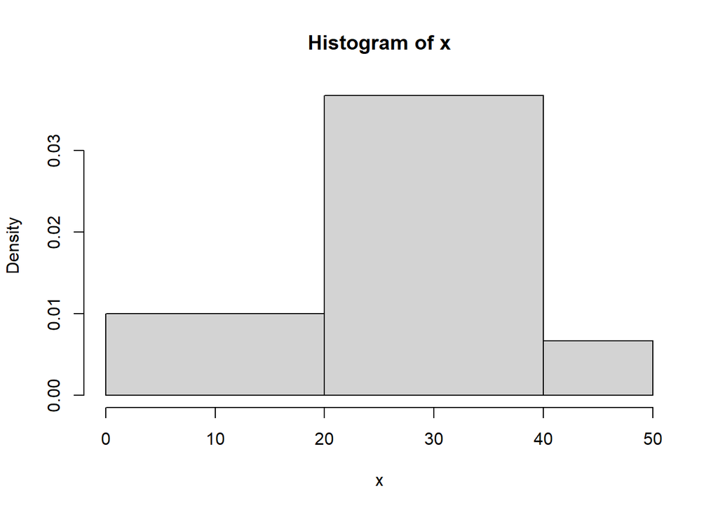

Figure 2: A histogram for our data set, based on the specified intervals. The third interval is narrower than the other two, and therefore densities are plotted on the vertical axis. This histogram does not show the features of our sample very clearly, so maybe it could be improved by making the wide intervals narrower.

```r
x <- c(18, 18, 19, 22, 22, 23, 25, 25, 25, 28, 30, 31, 33, 37, 41)

hist(x, breaks = c(0,20,40,50), right = FALSE, freq = FALSE)
```

## Solution to Exercise 6

Plugging in the summaries that are given into the sample correlation formula, we get
$$\begin{eqnarray*}
r_{xy} & = & \frac{\frac{1}{n-1}\sum_{i = 1}^{n} (x_i-\overline{x})(y_i-\overline{y})}{s_x s_y}\\
& = & \frac{\frac{1}{9}\sum_{i = 1}^{n} (x_i-10)(y_i-11.2)}{8.6 \times 7.4}\\
& \approx & \frac{\sum_{i = 1}^{n} (x_i-10)(y_i-11.2)}{573}.
\end{eqnarray*}$$
So we just need to calculate
$$\sum_{i = 1}^{n} (x_i-10)(y_i-11.2) = (3-10)(11-11.2) + \ldots + (30-10)(0-11.2) \approx -409.$$
Therefore
$$r_{xy} \approx \frac{-409}{573} \approx -0.7$$
as confirmed by the R code

```r
x <- c(3, 3.5, 4, 5, 6, 7, 10, 12, 19.5, 30)
y <- c(11, 11, 17, 13, 14, 24, 16,  3,  3,  0)
cor(x, y)
```

```
## [1] -0.7118596
```

We could have also calculated $\sum_{i = 1}^{n} (x_i-\overline{x})(y_i-\overline{y})$ in R using the `sum()` function,

```r
sum((x - mean(x))*(y - mean(y)))
```

```
## [1] -409
```

## Solution to Exercise 7

For parts a and b, we will use a binomial model. If so, we identify “success” with requiring conversion (of course, conversion is a negative outcome here, so “success” is just a label). Not requiring conversion is then “failure”. So we consider number of conversions to be random variable,
$$X \sim Bin(n,p)$$
with $p=0.2$ and $n=100$. Then

1. ${\mathsf P}(X=20) ={100\choose 20} 0.2^{20} 0.8^{80}=0.0993$.
2. We have to add the corresponding probabilities for $r=15, 16$. This is given by:
   $$\begin{eqnarray*}
   \sum_{r=15}^{16}{\mathsf P}(X=r) & = & \sum_{r=15}^{16}{100\choose r} 0.2^r 0.8^{100-r}\\
   & = & 0.0481 + 0.0638\\
   & = & 0.1119
   \end{eqnarray*}$$
3. For parts c and d, we could consider a new random variable: number of operations until the first conversion, $Y \sim \text{Geom}(p)$ with $p = 0.2$.
   $${\mathsf P}(Y = 2)=0.8^2 \times 0.2 = 0.128$$
4. We need
   $${\mathsf P}(Y \geq 10) = \sum_{r=10}^{\infty} {\mathsf P}(Y = r)= 0.2 \sum_{r=10}^{\infty} 0.8^{r}$$
   but it is easier to compute this by asking what is the probability that there are no conversion among the first $10$ cases. This is just binomially distributed, $Z \sim Bin(n, p)$ with $n=10$ and $p =0.2$, and we want
   $${\mathsf P}(Z=0) = {10\choose 0} 0.2^0 0.8^{10} =0.8^{10}=0.107.$$

## Solution to Exercise 8

By standardising, we have
$${\mathsf P}(X<3) = {\mathsf P}\left(\frac{X-\mu}{\sigma} < \frac{3-1}{2}\right) = {\mathsf P}(Z < 1)$$
where $Z\sim N(0,1)$ is a standard normal variable. This probability is $\Phi(1)$, which can be found from the tables to be $0.8413$.
$${\mathsf P}(X<-3) = {\mathsf P}\left(\frac{X-\mu}{\sigma} < \frac{-3-1}{2}\right) = {\mathsf P}(Z < -2) = \Phi(-2),$$
which we cannot find in our table. To use the tables remember that the standard normal distribution is symmetric about $0$, so ${\mathsf P}(Z<z) = {\mathsf P}(Z>-z)$. The total area under the normal curve is $1$, so
$${\mathsf P}(Z < -2) = {\mathsf P}(Z > 2) = 1-{\mathsf P}(Z < 2) = 1 - \Phi(2),$$
where $\Phi(2) = 0.9772$ in the tables. Therefore ${\mathsf P}(X<-3) = 1 - 0.9772 = 0.0228$.

## Solution to Exercise 9

The density function is $f(x) = 1/\theta$ for $x \in [0, \theta]$ and $f(x) = 0$ otherwise. The expectation is therefore
$$\begin{eqnarray*}
{\mathsf E}(X) & = & \int_{-\infty}^{\infty}xf(x)dx\\
& = & \int_{0}^{\theta}\frac{x}{\theta}d x\\
& = & \left[\frac{x^{2}}{2\theta}\right]_{0}^{\theta}
\;\; = \;\; \frac{\theta}{2}.
\end{eqnarray*}$$
To calculate the variance, we first need
$$\begin{eqnarray*}
{\mathsf E}(X^2) & = & \int_{-\infty}^{\infty}x^2f(x)dx\\
& = & \int_{0}^{\theta}\frac{x^2}{\theta}d x\\
& = & \left[\frac{x^{3}}{3\theta}\right]_{0}^{\theta}
\;\; = \;\; \frac{\theta^2}{3}.
\end{eqnarray*}$$
Then the variance is
$${\mathsf E}(X^2) - {\mathsf E}(X)^2 = \frac{\theta^2}{3} - \frac{\theta^2}{4} = \frac{\theta^2}{12}.$$
Since there is only one parameter to estimate here, the method of moments estimate is found by setting $\overline{x} \approx {\mathsf E}(X) = \theta/2$ and solving for $\theta$. This gives an estimate
$$\widehat{\theta} = 2\overline{x}.$$

## Solution to Exercise 10

When $X \sim Bin(1, p)$ the mass function is $p^x(1-p)^{(1-x)}$ for $x = 0, 1$ and $f(x) = 0$ otherwise. The likelihood function is therefore
$$\begin{eqnarray*}
L(p) & = & f(x_1)f(x_2)f(x_3)f(x_4) \\
& = & p^{x_1}(1-p)^{1-x_1}p^{x_2}(1-p)^{1-x_2}p^{x_3}(1-p)^{1-x_3}p^{x_4}(1-p)^{1-x_4}.
\end{eqnarray*}$$
Gathering together similar terms, this becomes
$$\begin{eqnarray*}
L(p) & = & p^{\sum_{i}x_i}(1-p)^{\sum_{i}(1-x_i)}\\
& = & p^{\sum_{i}x_i}(1-p)^{4-\sum_{i}x_i}\\
& = & p^{4\overline{x}}(1-p)^{4-4\overline{x}}.
\end{eqnarray*}$$
The log-likelihood is then
$$\begin{eqnarray*}
\ell(p) & = & \log L(p)\\
& = & \log p^{4\overline{x}} + \log(1-p)^{4-4\overline{x}}\\
& = & 4\overline{x}\log p + (4-4\overline{x})\log(1-p).
\end{eqnarray*}$$
Differentiating, we get
$$\frac{d\ell}{dp}(p) = \frac{4\overline{x}}{p} - \frac{4-4\overline{x}}{1-p},$$
which is the desired expression. To maximise the likelihood, we need to solve
$$\frac{d\ell}{dp}(p) = 0,$$
which is equivalent to
$$\frac{4\overline{x}}{p} = \frac{4-4\overline{x}}{1-p} \quad \Leftrightarrow \quad
{\overline{x}}(1 - p) = p({1-\overline{x}})$$
and gives $p = \overline{x} = (0 + 1 + 1 + 0)/4 = 1/2$. So $\widehat{p} = 1/2$ is a potential MLE for $p$. But does it actually maximise the likelihood?
$$\frac{d^2\ell}{dp^2}(p) = -\frac{4\overline{x}}{p^2} - \frac{4-4\overline{x}}{(1-p)^2}$$
which is clearly negative for all values of $p$, including $p = 1/2$. Therefore the log-likelihood (and thus the likelihood) is maximised at $p = 1/2$, so $\widehat{p} = 1/2$ is a maximum likelihood estimate for $p$.

Since we only have one unknown parameter, we find the method of moments estimate by setting $\overline{x} \approx {\mathsf E}(X)$. For a binomial distribution $Bin(1, p)$, we know that ${\mathsf E}(X) = 1\times p$. Therefore $\widehat{p} = \overline{x} = 1/2$ is also our method of moments estimate for $p$.

## Solution to Exercise 11

Given a sample $x_1,\ldots,x_n$ the likelihood function is a function of both $\mu$ and $\sigma$:
$$L(\mu, \sigma)=\prod_{i=1}^n \frac{1}{\sigma\sqrt{2\pi}}\exp\left\{-\frac{1}{2}\frac{(x_i-\mu)^2}{\sigma^2}\right\}$$
which can be simplified to
$$\frac{1}{\sigma^n(2\pi)^{n/2}}\exp\left\{-\frac{1}{2\sigma^2}\sum_{i=1}^n (x_i-\mu)^2\right\}.$$
We first take the natural logarithm
$$l(\mu, \sigma) = \log L(\mu,\sigma)= -n\log\sigma-\frac{n}{2}\log (2\pi)-\frac{1}{2\sigma^2}\sum_{i=1}^n (x_i-\mu)^2.$$
We can take the (partial) derivative and set it equal to zero,
$$\frac{\partial l(\mu,\sigma)}{\partial\mu} = \frac{2}{2\sigma^2}\sum_{i=1}^n (x_i-\mu)=0$$
and then we solve for $\mu$:
$$\sum_{i=1}^{n}x_i - n\mu = 0 \;\; \Leftrightarrow \;\; \mu = \frac{1}{n}\sum_{i=1}^n x_i.$$
So $\widehat{\mu} = \overline{x}$ is our estimator for $\mu$. Not surprisingly, this is the sample mean.

Now we take the partial derivative with respect to $\sigma$ and set that equal to $0$:
$$\frac{\partial l(\mu,\sigma)}{\partial\sigma} = -\frac{n}{\sigma}+\frac{2}{2\sigma^3}\sum_{i=1}^n (x_i-\mu)^2 =0.$$
Solving this, we get
$$\sigma^2 = {\frac{1}{n}\sum_{i=1}^n (x_i-\mu)^2}$$
as the value of $\sigma^2$ that maximises the log likelihood. But we don’t know $\mu$, so we plug in the estimator for $\mu$ to get an estimator for $\sigma^2$:
$$\widehat{\sigma^2} = {\frac{1}{n}\sum_{i=1}^n (x_i-\overline{x})^2}.$$
It is interesting to note here that the MLE for is **not** the same as the sample variance $s^2 = {\frac{1}{n-1}\sum_{i=1}^n (x_i-\overline{x})^2}$. But we have
$$\widehat{\sigma^2} = \frac{n-1}{n}s^2 \approx 1 \times s^2 = s^2$$
when $n$ is large, so these two estimators will usually be very similar in practice. Which estimator do we prefer? We see which estimator is preferred (and why) in the computer practicals.

## Solution to Exercise 12

**a.** Given that the density function is zero outside the interval $(0, \theta]$, the expectation is given by the integral
$$\begin{eqnarray*}
{\mathsf E}(X) & = & \int_{0}^{\theta}xf(x)dx\\
& = & \int_{0}^{\theta}\frac{2x^2}{\theta^2}dx\\
& = & \left[ \frac{2x^{3}/3}{\theta^2}\right]^{\theta}_{0}\\
& = & \frac{2\theta^{3}/3}{\theta^2} - 0
\;\; = \;\; \frac{2\theta}{3}.
\end{eqnarray*}$$
The variance is ${\mathsf E}(X^2) - {\mathsf E}(X)^2$, so we first calculate
$$\begin{eqnarray*}
{\mathsf E}(X^2) & = & \int_{0}^{\theta}x^2 f(x)dx\\
& = & \int_{0}^{\theta}\frac{2x^3}{\theta^2}dx\\
& = & \left[ \frac{2x^4 /4}{\theta^2}\right]^{\theta}_{0}
\;\; = \;\; \frac{\theta^2}{2}.
\end{eqnarray*}$$
Therefore $\text{var}(X) = \theta^2/2 - 4\theta^2/9 = (9 - 8)\theta^2/18 = \theta^2/18$.

**b.** According to the method of moments, we should solve ${\mathsf E}(X) \approx \overline{x}$, which is equivalent to
$$\frac{2\theta}{3} \approx \overline{x} \quad \Leftrightarrow \quad \theta = \frac{3\overline{x}}{2}.$$
Therefore the method of moments estimat**e** is $\widehat{\theta}_{mom} = 3\overline{x}/2$ and the method of moments estimat**or** is $\widehat{\theta}_{mom} = 3\overline{X}/2$.

**c.** The bias is
$$\begin{eqnarray*}
{\mathsf E}(\widehat{\theta}_{mom}) - \theta & = & {\mathsf E}\left(\frac{3}{2}\frac{\sum_{i=1}^{n}X_{i}}{n}\right) - \theta\\
& = & \frac{3}{2}\frac{\sum_{i=1}^{n}{\mathsf E}(X_{i})}{n} - \theta
\end{eqnarray*}$$
by linearity. But ${\mathsf E}(X_{i}) = 2\theta/3$ since the $X_i$ are identically distributed, so
$$\begin{eqnarray*}
\text{bias}(\widehat{\theta}_{mom}) & = & \frac{3}{2}\frac{\sum_{i=1}^{n}2\theta/3}{n} - \theta\\
& = & \frac{3}{2}\frac{2n\theta/3}{n} - \theta = 0.
\end{eqnarray*}$$
Therefore the estimator is unbiased. The MSE is then
$$\begin{eqnarray*}
\text{var}(\widehat{\theta}_{mom}) + \text{bias}(\widehat{\theta}_{mom})^2 & = & \text{var}\left(\frac{3}{2}\frac{\sum_{i=1}^{n}X_{i}}{n}\right) + 0 \\
& = & \frac{9}{4}\frac{\sum_{i=1}^{n}\text{var}(X_{i})}{n^2}\\
& = & \frac{9}{4}\frac{\sum_{i=1}^{n}\theta^2/18}{n^2}
\;\; = \;\; \frac{\theta^2/8}{n},
\end{eqnarray*}$$
where we have used the independence assumption to express the variance of a sum as the sum of the variances of each term. The MSE shrinks as $n$ is increases, suggesting that the estimator performs better for larger sample sizes, as we would hope.

**d.** Since each $x_{i}$ will be in the interval $(0, \theta]$, the likelihood is
$$L(\theta) = \frac{2x_{1}}{\theta^2}\cdots \frac{2x_{n}}{\theta^2} = 2^n\theta^{-2n}\prod_{i=1}^{n}x_{i}.$$
The log likelihood is then
$$\begin{eqnarray*}
\ell(\theta) & = & \log 2^n + \log\theta^{-2n} + \log\prod_{i=1}^{n}x_{i}\\ & = & -2n\log(\theta) + n\log 2 + \sum_{i=1}^{n}\log x_{i}.
\end{eqnarray*}$$
Given that $-2n\log(\theta)$ is a decreasing function of $\theta$ and is the only part of the log likelihood that depends on $\theta$, we maximise it by choosing $\theta$ to be as small as possible. The only constraints here are that $\theta >0$ and $\theta \geq x_{i} > 0$ for each realisation. Therefore the maximum likelihood estimate is,
$$\widehat{\theta}_{mle} = max \{x_{1}, \ldots, x_{n}\},$$
the largest of our $n$ realisations. Our maximum likelihood estimat**or** is therefore
$$\widehat{\theta}_{mle} = max \{X_{1}, \ldots, X_{n}\}.$$

**Some notes about this exercise:**

- When there is **only one** unknown parameter, you find the method of moments estimate by solving
  $$\overline{x} \approx {\mathsf E}(X)$$
  for $\theta$. You only need to consider the variance when there are **two** unknown parameters.
- The bias is the difference between ${\mathsf E}(\widehat{\theta})$ and the **true value** of the parameter, $\theta$. It is **not** the difference between ${\mathsf E}(\widehat{\theta})$ and the estimator $\widehat{\theta}$.
- The bias and MSE **should** usually depend on the unknown parameters and on the sample size. So don’t panic even if they end up being fairly complicated functions of $\theta$ and $n$.
- The bias and MSE **should not** depend on the sample itself. If you find a bias that depends on $X_{1}, \ldots, X_{n}$ then that’s a sign that you might have done something wrong.

## Solution to Exercise 13

**a.** Since there is only one unknown parameter to estimate, we propose that the sample mean is approximately equal to the expectation:
$$\overline{x} \approx {\mathsf E}(X)$$
and then solve for $\alpha$.

To find the expectation as a function of $\alpha$, we use the definition of expectation:
$$\begin{eqnarray*}
{\mathsf E}(X) & = & \sum_{x\in\{-1, 0, 1\}}x f(x)\\
& = & -1(-\alpha + 0.1) + 0(-\alpha + 0.8) + 1(2\alpha + 0.1)\\
& = & 3\alpha.
\end{eqnarray*}$$

Then, to find our estimate,
$$\begin{eqnarray*}
\overline{x} \approx {\mathsf E}(X) & \Leftrightarrow & \overline{x} \approx 3\alpha \\
& \Leftrightarrow & \alpha \approx \overline{x}/3
\end{eqnarray*}$$
which suggests an estimator $\widehat\alpha = \overline{X}/3$.

The bias is
$${\mathsf E}(\widehat{\alpha}) - \alpha$$
and we can use linearity of expectations to see that
$$\begin{eqnarray*}
{\mathsf E}(\widehat{\alpha}) & = & {\mathsf E}\left(\frac{1}{3}\overline{X}\right)\\
& = & {\mathsf E}\left(\frac{1}{3}\frac{1}{n}\sum_{i=1}^{n}{X_i}\right)\\
& = & \frac{1}{3n}{\mathsf E}\left(\sum_{i=1}^{n}{X_i}\right)\\
& = & \frac{1}{3n}\sum_{i=1}^{n}{\mathsf E}({X_i})
\end{eqnarray*}$$
where, since our sample is identically distributed, ${\mathsf E}({X_i}) = 3\alpha$, and therefore
$${\mathsf E}(\widehat{\alpha}) = \frac{1}{3n}\sum_{i=1}^{n}3\alpha = \frac{1}{3n}n3\alpha = \alpha.$$

This implies that the bias is 0 and therefore our estimator is unbiased.

The MSE is $\text{var}\left(\widehat{\alpha}\right) + \text{bias}^2$ which, since our estimator is unbiased, must just be equal to the variance of $\widehat{\alpha}$:
$$\begin{eqnarray*}
\text{var}\left(\widehat{\alpha}\right) & = & \text{var}\left(\frac{1}{3n}\sum_{i=1}^{n}{X_i}\right)\\
& = & \left(\frac{1}{3n}\right)^2\text{var}\left(\sum_{i=1}^{n}{X_i}\right)\\
& = & \left(\frac{1}{3n}\right)^2\sum_{i=1}^{n}\text{var}(X_i)\\
& = & \left(\frac{1}{3n}\right)^2n\text{var}(X),
\end{eqnarray*}$$
where the last two steps use the independent and identically distributed assumptions.
$$\text{var}(X) = {\mathsf E}(X^2) - {\mathsf E}(X)^2$$
and we can see that
$$\begin{eqnarray*}
{\mathsf E}(X^2) & = & \sum_{x\in\{-1, 0, 1\}}x^2 f(x)\\
& = & (-1)^2(-\alpha + 0.1) + 0^2(-\alpha + 0.8) + 1^2(2\alpha + 0.1)\\
& = & \alpha + 0.2,
\end{eqnarray*}$$
which implies
$$\text{var}(X) = {\mathsf E}(X^2) - {\mathsf E}(X)^2 = \alpha + 0.2 - 9\alpha^2.$$
Finally, we have
$$MSE = \text{var}\left(\widehat{\alpha}\right) = \frac{1}{9n}\text{var}(X) = \frac{\alpha + 0.2 - 9\alpha^2}{9n}$$
as the mean squared error.

**b.** If $n$ is large, the central limit theorem tells us that $\overline{X}$ is approximately normally distributed. Therefore $\widehat{\alpha} = \overline{X}/3$ is also approximately normally distributed with mean and variance as calculated above:
$$\widehat{\alpha} \;\;\sim\;\; N\left(\alpha \;,\; \frac{\alpha + 0.2 - 9\alpha^2}{9n}\right).$$
As $n$ increases, the variance of this distribution shrinks towards $0$, suggesting that our estimates will be more concentrated around $\alpha$ when our samples are large.

**c.** If we take a sample of size $n=1$, we have a sample consisting of one realisation: $\{x_1\}$. The likelihood is therefore just the mass function, evaluated at $x_1$, treated as a function of $\alpha$:
$$L(\alpha) = f(x_1) = \left\{\begin{array}{ll}
-\alpha + 0.1 & \;\;\textrm{if } x_1 = -1,\\
-\alpha + 0.8 & \;\;\textrm{if } x_1 = 0.\\
2\alpha + 0.1 & \;\;\textrm{if } x_1 = 1.\\
\end{array}\right.$$
We have three cases:

- If $x_1 = -1$ then $L(\alpha) = -\alpha + 0.1$ is maximised at $\alpha = 0$, so our MLE is $\widehat{\alpha} = 0$.
- If $x_1 = 0$ then $L(\alpha) = -\alpha + 0.8$ is maximised at $\alpha = 0$, so our MLE is $\widehat{\alpha} = 0$.
- If $x_1 = 1$ then $L(\alpha) = 2\alpha + 0.1$ is maximised at $\alpha = 0.1$, so our MLE is $\widehat{\alpha} = 0.1$.

**d.** If we take a sample of size $n = 2$ an observe $x_1 = -1$ and $x_2 = -1$, then the likelihood of this sample is a product:
$$L(\alpha) = f(x_1)f(x_2) = f(-1)f(-1) = (-\alpha + 0.1)^2$$
and the log likelihood is
$$\ell(\alpha) = \log(-\alpha + 0.1)^2 = 2\log(-\alpha + 0.1) .$$
We differentiate to get
$$\frac{d\ell}{d\alpha} = \frac{-2}{-\alpha + 0.1}$$
When $\alpha < 0.1$, we know that $-\alpha + 0.1>0$ and therefore $d\ell/d\alpha < 0$, so the log likelihood is a decreasing function of $\alpha$. The log likelihood (and thus the likelihood) is therefore maximised when $\alpha = 0$. We know $\alpha \neq 0.1$, because then ${\mathsf P}(X = -1) = f(-1) = 0$ and we could not have observed $-1$ in our sample. Therefore our MLE is $\widehat\alpha = 0$.

## Solution to Exercise 14

We will have (approximately) $\overline X \sim N(\mu,\sigma^2/n)$ with $\mu=50, \sigma=15$ and $n=90$. So we assume
$$\overline X \sim N(50,15^2/90).$$

We want ${\mathsf P}({\overline X>52})$. Standardizing, we obtain:
$$\begin{eqnarray*}
{\mathsf P}({\overline X>52}) & = & {\mathsf P}\left({\frac{\overline X-\mu}{\sigma/\sqrt{n}}>\frac{52-50}{15/\sqrt{90}}}\right)\\ & \approx & {\mathsf P}({Z>1.2649})\approx 0.10295.
\end{eqnarray*}$$
Similarly,
$$\begin{eqnarray*}
{\mathsf P}({\overline X<45}) & = & {\mathsf P}\left({\frac{\overline X-\mu}{\sigma/\sqrt{n}}<\frac{45-50}{15/\sqrt{90}}}\right)\\
& \approx & {\mathsf P}({Z<-3.16}) \approx 0.0008.
\end{eqnarray*}$$
Similarly,
$$\begin{eqnarray*}
{\mathsf P}({45<\overline X<55}) & = & {\mathsf P}\left({\frac{45-50}{15/\sqrt{90}}<\frac{\overline X-\mu}{\sigma/\sqrt{n}}<\frac{55-50}{15/\sqrt{90}}}\right)\\
& \approx & {\mathsf P}({-3.16<Z<3.16}) \approx 0.998.
\end{eqnarray*}$$
Finally, we solve for $c$ such that
$${\mathsf P}\left({-c<\frac{\overline X -\mu}{\sigma/\sqrt{n}}< c}\right)=0.9$$
i.e.
$${\mathsf P}({-c<Z< c})=0.9\quad\text{where}\quad Z\sim N(0,1).$$
But this is equivalent to ${\mathsf P}(Z< c) = 0.95$ (draw a picture if you’re not sure why). We can then find $c$ from the tables, which give $c \approx 1.64$.

## Solution to Exercise 15

We will carry out the test with $\alpha=0.05$, and so the rejection region is given by $|T|>2.101=t_{18}(0.025)$. The summary statistics are: $\overline d=0.03368421, s^2=0.003569$. The test statistic is
$$t=\frac{\overline d -0}{\sqrt{s^2/n}}=\frac{0.03368421}{0.0137}=2.4577$$
Our decision, since $|2.4577| > 2.101$ is to reject $H_0$ and conclude that the difference in the proportions has changed between $1968$ and $1972$.

The p-value is the probability of obtaining a test statistic “at least as far from $H_0$ as the one we have observed”. Here, it is
$${\mathsf P}(|T|>t)={\mathsf P}(|T|>2.4577)\qquad T\sim t_{18}.$$

Using R, we find that this p-value is $0.024$.

A type 1 error would be rejecting a true null: concluding that there was a change in participation rates between $1972$ and $1968$ when, in fact, they were exactly the same in both years. A type 2 error would be a failure to reject a false null: incorrectly concluding that female labour force participation was the same in $1972$ as it was four years before.

Alternatively, we could have calculated a $95\%$-confidence interval for $\delta$ to test our hypothesis:
$$\overline{d} \pm t_{18}(0.025)\sqrt{s^2/n} = 0.03368421 \pm 2.101\sqrt{0.003569/19}$$
which gives us an interval estimate of approximately $(0.5\%, 6.2\%)$. This interval does not contain $0$, so we can reject the hypothesis that $\delta = 0$.

## Solution to Exercise 16

1. The data are paired, with two measurements made on each of five individuals. Two measurements in the same individual are unlikely to be independent. The correlation suggests that there might be a linear relationship between the measurements made before and during revision, which would violate an independence assumption (independent variables should be uncorrelated).
2. We should apply a one sample t-test to the differences, $d_i$, between the paired observations. First, we need the necessary summary statistics:

   | $i$ | 1 | 2 | 3 | 4 | 5 |
   | --- | --- | --- | --- | --- | --- |
   | $x_{i}$ | 90 | 80 | 60 | 80 | 50 |
   | $y_{i}$ | 50 | 60 | 20 | 20 | 10 |
   | $d_{i} = y_{i} - x_{i}$ | -40 | -20 | -40 | -60 | -40 |
   | $(d_i - \overline{d})^2$ | 0 | 400 | 0 | 400 | 0 |

   $$\overline{d} = \frac{1}{n}\sum_i d_i = \frac{1}{5}(-200) = -40$$
   $$s^2 = \frac{1}{n-1}\sum_i (d_i - \overline{d})^2 = \frac{1}{4}(400 + 400) = 200$$
   Our confidence interval will be
   $$\overline{d} \pm t_{n-1}(\frac{\alpha}{2})\sqrt{\frac{s^2}{n}} = -40 \pm t_{4}(0.005)\sqrt{\frac{200}{5}}$$
   where $\alpha = 1\%$ is our chosen significance level (so that $100\% - \alpha = 99\%$), and $s^2$ is the sample variance of the observed differences. From the tables we need to find $t_{4}(0.005)$, the $99.5\%$ quantile of $t_{4}$, so we look for $P = 0.5\%$ and $\nu = 4$:
   $$t_{4}(0.005) = 4.604$$
   Then our confidence limits are:
   $$-40 \pm 4.604\sqrt{\frac{200}{5}}$$
   which gives an interval estimate of approximately $(-69, -11)$. Our assumptions here are that the **differences** are an independent sample of size $n=5$ and that the distribution of differences is a **normal** distribution.
3. The interval **does not** contain $0$, so we can reject (at the 1% significance level) the null hypothesis that revision has no effect on the average quality of life in our population of MSc students. Since the interval only contains negative numbers, this suggests that revision has the effect of reducing quality of life. It suggests that the average reduction is at least $11$ points.
4. type 1 error means an incorrect rejection of the null: concluding that revision affects average quality of life (either positively or negatively) when it actually does not. type 2 error means a failure to reject a false null: concluding that there is no difference in average quality of life when, in reality, there is.
5. The skew suggests that our normal distribution assumption is inappropriate, since a normal distribution is symmetrical. We could instead construct a confidence interval (still using the differences, $d_i$) based on the central limit theorem, which does not require us to assume a specific distribution. Given that the sample size is very large, we would expect the sample variance to be a good approximation of the population variance (of the differences) and could therefore reasonably assume $\sigma^2 = s^2$ in our calculation.

## Solution to Exercise 18

1. Binomial, since the binomial distribution models the number of successes in $n$ independent trials with probability $\theta$.
2. The p-value for the observed data here is the probability (assuming $H_{0}$ is true) of observing $X$ to be at least as extreme (i.e. at least as far from $5$) as our observation ($9$). This means we need the probability that $X$ is either $\geq 9$ or $\leq 1$:
   $$p = {\mathsf P}(X \geq 9) + {\mathsf P}(X \leq 1).$$
   But note that ${\mathsf P}(X \geq 9) = {\mathsf P}(X \leq 1)$ since the probability of $9$ or $10$ heads on a fair coin (remember we are assuming $H_0$) is equal to the probability of $9$ or $10$ tails (equivalently, $1$ or $0$ heads). Thus,
   $$p = 2{\mathsf P}(X \geq 9) = 2(1 - {\mathsf P}(X \leq 8)) = 2(1- 0.99) = 0.02.$$
3. This would be rejection of a true null, i.e a type 1 error.

# Solutions to exam questions

The following are solutions to questions from past exam papers. We are not allowed to provide full model solutions to these, and therefore the solutions given are only brief. Please do not assume that it is acceptable to give answers with this level of detail in the real exam. You should always try to answer exam questions as clearly as possible, showing the steps in any calculations and explaining the reasoning behind any statements or assumptions that you make.

## Solution to Exercise 19

1. t-test, and correct justification for this choice should be given.
2. Marks awarded for a generally correct approach and for the correct conclusion.
3. type 1 error if the null is rejected, otherwise neither.

## Solution to Exercise 20

1. Both estimators are unbiased.
2. $\text{var}(\widehat{\mu}_1) = \frac{1}{2}$ and $\text{var}(\widehat{\mu}_2) = \frac{5}{9}$.
3. The first estimator would be preferred.

## Solution to Exercise 21

This answer must have: clearly stated hypotheses, a sensible explanation of a type 1 error, a sensible explanation of a type 2 error.

## Solution to Exercise 22

1. A density function must take non-negative values.
2. $\widehat{\gamma} = n/\sum_i x_i^2 = 3/6 = 1/2$.
3. `f <- function(x, gamma){return(2*gamma*x*exp(-gamma*x^2))}`

## Solution to Exercise 23

1. Marks awarded for each of the following:
   - The correlation is actually quite high.
   - The CDFs show a clear difference in estimated probabilities.
   - Difference in location tells us nothing about skew.
   - The central limit theorem tells us about the distribution of the sample mean.
   - Independence assumptions of the t-test are violated here.
   - The test performed does not assume equal variances.
   - The significance level here is $5\%$, not $2.5\%$.
   - The conclusion based on the the confidence interval is too strong.
2. Treat the data as paired, check normality via quantile plots, then apply either a z-test or a t-test to the differences.
3. The $80\%$ sample quantile is about $7500$ seconds. ${\mathsf P}(X < 8000)\approx 0.95$ and ${\mathsf P}(X \leq 18000) \approx 1$. Thus, the probability of taking between $8000$ and $18000$ seconds is roughly $5\%$. (Your answer doesn’t have to be exactly the same as mine here, and it’s really the reasoning used to produce that number that matters.)
1. About a $60\%$ chance of our $200$ simulations taking longer than $16$ days.